# Fitbit Daily Activity: Behaviroal Patterns and Energy Expenditure

Mitchell Talton

## 1 Overview

This notebook explores daily activity patterns from a public Fitbit dataset, focusing on: 1) **Behavioral variability** (weekday vs weekend step patterns)  
2) **Physiological relationship** (steps vs calories burned)

To improve interpretability, analysis is performed at the **individual-user** level.

## 2 Load Libraries

```r
library(tidyverse)
library(lubridate)

theme_set(theme_minimal(base_size=13))
```

## 3 Load Data

```r
daily_data <- read_csv("dailyActivity_merged.csv", show_col_types = FALSE)

glimpse(daily_data)
```

```
## Rows: 940
## Columns: 15
## $ Id                       <dbl> 1503960366, 1503960366, 1503960366, 150396036…
## $ ActivityDate             <chr> "4/12/2016", "4/13/2016", "4/14/2016", "4/15/…
## $ TotalSteps               <dbl> 13162, 10735, 10460, 9762, 12669, 9705, 13019…
## $ TotalDistance            <dbl> 8.50, 6.97, 6.74, 6.28, 8.16, 6.48, 8.59, 9.8…
## $ TrackerDistance          <dbl> 8.50, 6.97, 6.74, 6.28, 8.16, 6.48, 8.59, 9.8…
## $ LoggedActivitiesDistance <dbl> 0, 0, 0, 0, 0, 0, 0, 0, 0, 0, 0, 0, 0, 0, 0, …
## $ VeryActiveDistance       <dbl> 1.88, 1.57, 2.44, 2.14, 2.71, 3.19, 3.25, 3.5…
## $ ModeratelyActiveDistance <dbl> 0.55, 0.69, 0.40, 1.26, 0.41, 0.78, 0.64, 1.3…
## $ LightActiveDistance      <dbl> 6.06, 4.71, 3.91, 2.83, 5.04, 2.51, 4.71, 5.0…
## $ SedentaryActiveDistance  <dbl> 0, 0, 0, 0, 0, 0, 0, 0, 0, 0, 0, 0, 0, 0, 0, …
## $ VeryActiveMinutes        <dbl> 25, 21, 30, 29, 36, 38, 42, 50, 28, 19, 66, 4…
## $ FairlyActiveMinutes      <dbl> 13, 19, 11, 34, 10, 20, 16, 31, 12, 8, 27, 21…
## $ LightlyActiveMinutes     <dbl> 328, 217, 181, 209, 221, 164, 233, 264, 205, …
## $ SedentaryMinutes         <dbl> 728, 776, 1218, 726, 773, 539, 1149, 775, 818…
## $ Calories                 <dbl> 1985, 1797, 1776, 1745, 1863, 1728, 1921, 203…
```

## 4 Data Cleaning Data and Feature Engineering

```r
daily_data <- daily_data %>%
  mutate(
    ActivityDate = as.Date(ActivityDate, format = "%m/%d/%Y"),
    DayOfWeek = wday(ActivityDate, label = TRUE, abbr = FALSE),
    DayType = if_else(DayOfWeek %in% c("Saturday", "Sunday"), "Weekend", "Weekday")
  )
```

```r
stopifnot(!all(is.na(daily_data$ActivityDate)))
summary(daily_data$TotalSteps)
```

```
##    Min. 1st Qu.  Median    Mean 3rd Qu.    Max.
##       0    3790    7406    7638   10727   36019
```

## 5 Single-User Selection

```r
#Wearable datasets often contain multiple participants. For clear visual storytelling, I will focus on one user.
user_id <- daily_data$Id %>% unique() %>% .[1]

user_data <- daily_data %>%
  filter(Id == user_id) %>%
  filter(!is.na(TotalSteps), !is.na(Calories)) %>%
  arrange(ActivityDate)

range(user_data$ActivityDate)
```

```
## [1] "2016-04-12" "2016-05-12"
```

## 6 Behavioral Pattern: Steps by Day Type

**Question:** Do step counts differ between weekdays and weekends for this user?

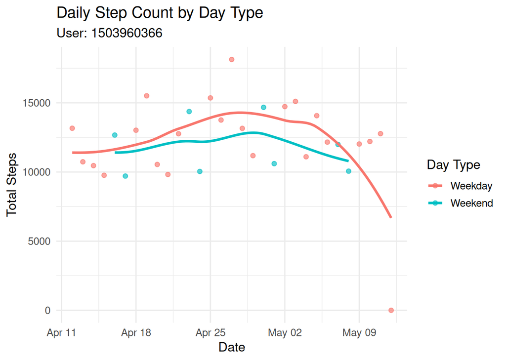

```r
ggplot(user_data, aes(x = ActivityDate, y = TotalSteps, color = DayType)) +
  geom_point(alpha = 0.65) +
  geom_smooth(se = FALSE, method = "loess") +
  labs(
    title = "Daily Step Count by Day Type",
    subtitle = paste("User:", user_id),
    x = "Date",
    y = "Total Steps",
    color = "Day Type"
  )
```

## 7 Physiological Context: Steps vs Calories

**Question:** How strongly does locomotor activity (steps) relate to energy expenditure (calories)?

```r
user_eff <- user_data %>%
  filter(TotalSteps >= 2000) %>%
  mutate(CaloriesPerStep = Calories / TotalSteps)

summary(user_eff$CaloriesPerStep)
```

```
##    Min. 1st Qu.  Median    Mean 3rd Qu.    Max.
##  0.1191  0.1393  0.1511  0.1526  0.1689  0.1808
```

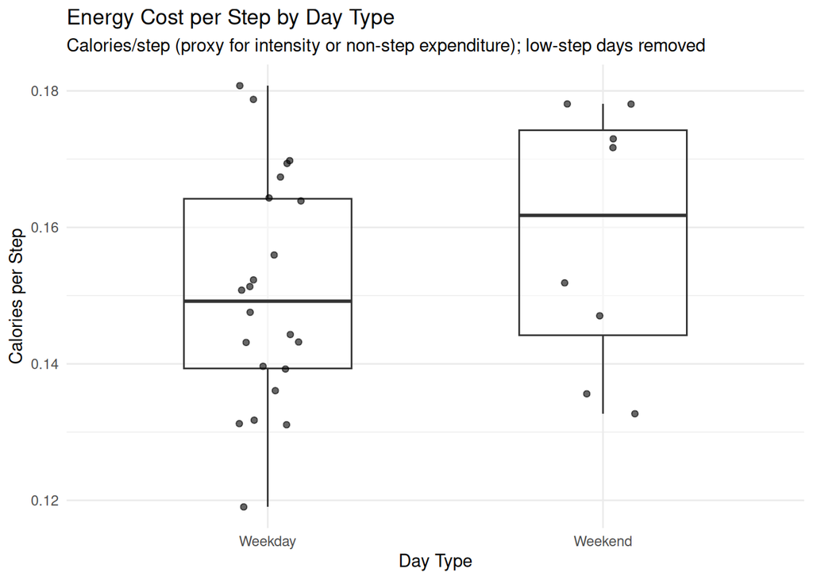

```r
ggplot(user_eff, aes(x = DayType, y = CaloriesPerStep)) +
  geom_boxplot(width = 0.5, outlier.shape = NA, alpha = 0.5) +
  geom_jitter(width = 0.12, alpha = 0.6) +
  labs(
    title = "Energy Cost per Step by Day Type",
    subtitle = "Calories/step (proxy for intensity or non-step expenditure); low-step days removed",
    x = "Day Type",
    y = "Calories per Step"
  ) +
  theme_minimal()
```

```r
user_eff %>%
  group_by(DayType) %>%
  summarise(
    Days = n(),
    Mean_CalPerStep = mean(CaloriesPerStep),
    Median_CalPerStep = median(CaloriesPerStep),
    .groups = "drop"
  )
```

```
## # A tibble: 2 × 4
##   DayType  Days Mean_CalPerStep Median_CalPerStep
##   <chr>   <int>           <dbl>             <dbl>
## 1 Weekday    22           0.150             0.149
## 2 Weekend     8           0.159             0.162
```

**Interpretation:**Calories per step serves as a simple proxy for energy cost per unit movement. Differences by day type may reflect changes in activity intensity (e.g., more vigorous movement on weekends) or additional non-step energy expenditure. Low-step days were excluded to reduce ratio inflation.

## 8 Quantifying Weekday vs. Weekend Differences

```r
library(scales)
summary_table <- user_eff %>%
  group_by(DayType) %>%
  summarise(
    Days = n(),
    MeanSteps = mean(TotalSteps),
    MedianSteps = median(TotalSteps),
    MeanCalories = mean(Calories),
    MedianCalories = median(Calories),
    MeanCalPerStep = mean(CaloriesPerStep),
    MedianCalPerStep = median(CaloriesPerStep),
    .groups = "drop"
  )

summary_table
```

```
## # A tibble: 2 × 8
##   DayType  Days MeanSteps MedianSteps MeanCalories MedianCalories MeanCalPerStep
##   <chr>   <int>     <dbl>       <dbl>        <dbl>          <dbl>          <dbl>
## 1 Weekday    22    12796.       12767        1893.          1878.          0.150
## 2 Weekend     8    11764.       11297        1832           1820.          0.159
## # ℹ 1 more variable: MedianCalPerStep <dbl>
```

```r
# Wide format for quick comparisons
diff_table <- summary_table %>%
  select(DayType, MeanSteps, MeanCalories, MeanCalPerStep) %>%
  pivot_wider(names_from = DayType, values_from = c(MeanSteps, MeanCalories, MeanCalPerStep)) %>%
  mutate(
    Steps_Diff = MeanSteps_Weekend - MeanSteps_Weekday,
    Calories_Diff = MeanCalories_Weekend - MeanCalories_Weekday,
    CalPerStep_Diff = MeanCalPerStep_Weekend - MeanCalPerStep_Weekday
  )

diff_table
```

```
## # A tibble: 1 × 9
##   MeanSteps_Weekday MeanSteps_Weekend MeanCalories_Weekday MeanCalories_Weekend
##               <dbl>             <dbl>                <dbl>                <dbl>
## 1            12796.            11764.                1893.                 1832
## # ℹ 5 more variables: MeanCalPerStep_Weekday <dbl>,
## #   MeanCalPerStep_Weekend <dbl>, Steps_Diff <dbl>, Calories_Diff <dbl>,
## #   CalPerStep_Diff <dbl>
```

**Takeaway:** Weekday vs weekend differences are summarized above to support interpretation of behavioral structure (steps) and relative energy cost (calories/step).

## 9 Activity Consistency

```r
consistency <- user_data %>%
  group_by(DayType) %>%
  summarise(
    Days = n(),
    MeanSteps = mean(TotalSteps, na.rm = TRUE),
    SDSteps = sd(TotalSteps, na.rm = TRUE),
    CVSteps = SDSteps / MeanSteps,
    .groups = "drop"
  )

consistency
```

```
## # A tibble: 2 × 5
##   DayType  Days MeanSteps SDSteps CVSteps
##   <chr>   <int>     <dbl>   <dbl>   <dbl>
## 1 Weekday    23    12239.   3375.   0.276
## 2 Weekend     8    11764.   1986.   0.169
```

**Interpretation:** CV (coefficient of variation) reflects consistency. Lower CV indicates more stable routine-driven activity patterns.

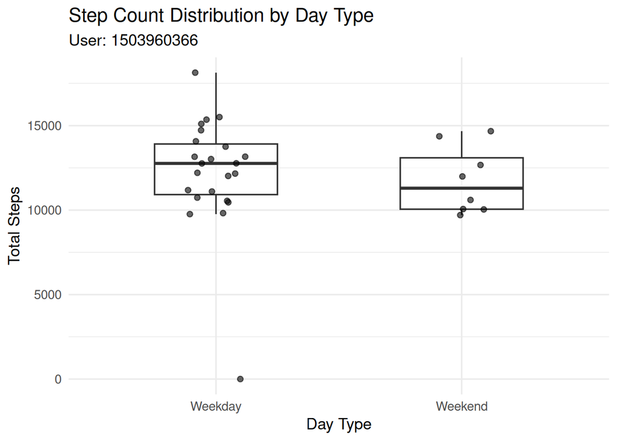

```r
ggplot(user_data, aes(x = DayType, y = TotalSteps)) +
  geom_boxplot(width = 0.5, outlier.shape = NA, alpha = 0.5) +
  geom_jitter(width = 0.12, alpha = 0.6) +
  labs(
    title = "Step Count Distribution by Day Type",
    subtitle = paste("User:", user_id),
    x = "Day Type",
    y = "Total Steps"
  )
```

## 10 Calories per Step vs. Steps:

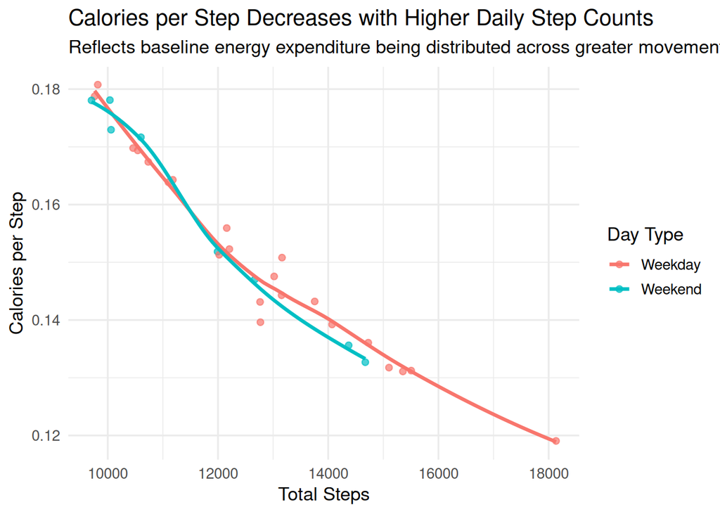

```r
ggplot(user_eff, aes(x = TotalSteps, y = CaloriesPerStep, color = DayType)) +
  geom_point(alpha = 0.7) +
  geom_smooth(se = FALSE, method = "loess") +
  labs(
  title = "Calories per Step Decreases with Higher Daily Step Counts",
  subtitle = "Reflects baseline energy expenditure being distributed across greater movement volume",
  x = "Total Steps",
  y = "Calories per Step",
  color = "Day Type"
)
```

**Interpretation:**Calories per step decreases as daily step count increases because total daily energy expenditure includes baseline metabolic processes (e.g., BMR and non-locomotor activity). As step count rises, this fixed baseline is distributed across greater movement volume, lowering the calories-per-step ratio. This demonstrates a limitation of ratio-based metrics and reinforces the importance of separating behavioral volume (steps) from physiological cost when interpreting wearable data.